# Practical_C

Gerko Vink

Statistical Programming with R

We use the following packages:

```r
library(class)
library(mvtnorm)
library(dplyr)
library(magrittr)
library(ggplot2)
```

1. **Reproduce the data from slide 18 twice, but now instead of $\pm 1.5$ use an adjustment of $\pm .5$ and $\pm 2.5$, respectively**

First we create the data:

```r
set.seed(123)
sigma <- matrix(c(1, .5, .5, 1), 2, 2)
sim.data <- rmvnorm(n = 100,
                    mean = c(5, 5),
                    sigma = sigma)
colnames(sim.data) <- c("x1", "x2")
```

add some clustering

```r
sim.data <-
  sim.data %>%
  as_tibble %>%
  mutate(class = sample(c("A", "B", "C"), size = 100, replace = TRUE))
```

and add the adjustments to the data

```r
sim.data.half <-
  sim.data %>%
  mutate(x2 = case_when(class == "A" ~ x2 + .5,
                        class == "B" ~ x2 - .5,
                        class == "C" ~ x2 + .5),
         x1 = case_when(class == "A" ~ x1 - .5,
                        class == "B" ~ x1 - 0,
                        class == "C" ~ x1 + .5))
sim.data.twohalf <-
  sim.data %>%
  mutate(x2 = case_when(class == "A" ~ x2 + 2.5,
                        class == "B" ~ x2 - 2.5,
                        class == "C" ~ x2 + 2.5),
         x1 = case_when(class == "A" ~ x1 - 2.5,
                        class == "B" ~ x1 - 0,
                        class == "C" ~ x1 + 2.5))
```

2. **Add a column to the data sets that indicates a `Train` (25%) and a `Test` (75%) part.**

```r
sim.data.half %<>%
  mutate(set = sample(c("Train", "Test"), size=100, prob = c(.25, .75), replace=TRUE))
sim.data.twohalf %<>%
  mutate(set = sample(c("Train", "Test"), size=100, prob = c(.25, .75), replace=TRUE))
```

3. **Fit the `K-NN` model to both data sets. Use `k = 3`.** For the first model with the `.5` adjustment:

```r
# create training and test
train.half <- subset(sim.data.half, set == "Train", select = c(x1, x2))
class.half <- subset(sim.data.half, set == "Train", select = class)
test.half <- subset(sim.data.half, set == "Test", select = c(x1, x2))

#run k-nn model
fit.knn.half <- knn(train = train.half,
                    test = test.half,
                    cl = as.matrix(class.half),
                    k = 3)
```

Then for the model with the `2.5` adjustment:

```r
# create training and test
train.twohalf <- subset(sim.data.twohalf, set == "Train", select = c(x1, x2))
class.twohalf <- subset(sim.data.twohalf, set == "Train", select = class)
test.twohalf <- subset(sim.data.twohalf, set == "Test", select = c(x1, x2))

#run k-nn model
fit.knn.twohalf <- knn(train = train.twohalf,
                       test = test.twohalf,
                       cl = as.matrix(class.twohalf),
                       k = 3)
```

4. **What is the percentage of correct predictions for each model?** For the `.5` adjustment data:

```r
class.test.half <- subset(sim.data.half, set == "Test", select = class) %>%
  as.matrix()
correct.half <- fit.knn.half == class.test.half
mean(correct.half)
```

```
## [1] 0.3846154
```

and for the `2.5` adjustment data:

```r
class.test.twohalf <- subset(sim.data.twohalf, set == "Test", select = class) %>%
  as.matrix()
correct.twohalf <- fit.knn.twohalf == class.test.twohalf

mean(correct.twohalf)
```

```
## [1] 0.9866667
```

The model based on the 2.5 adjustment data performs much better. But in this model the classes are also more separated.

5. **Plot the false and correct predictions for both models.** For the `.5` adjustment data:

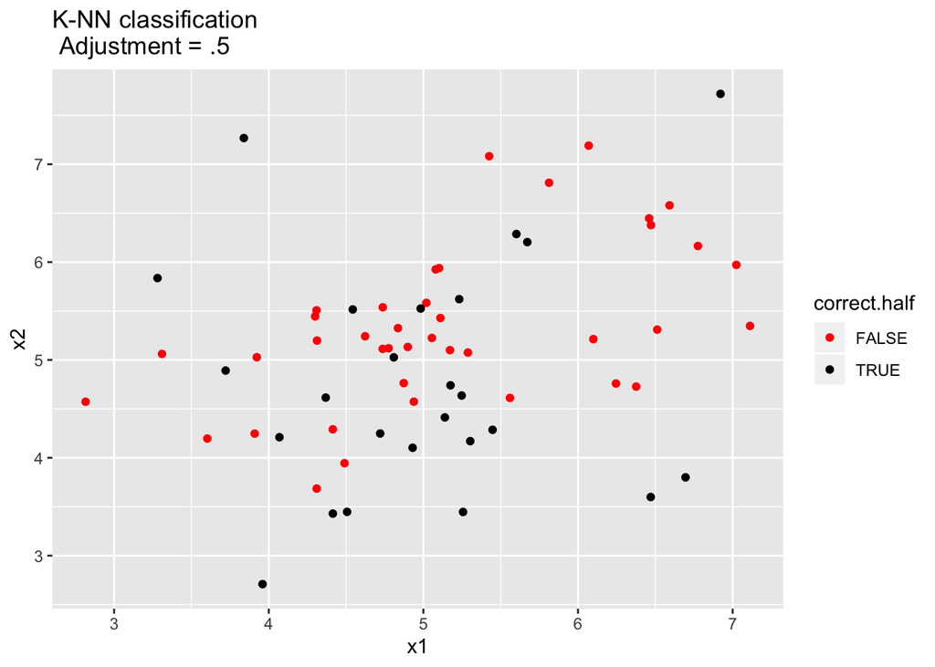

```r
cbind(test.half, correct.half) %>%
  ggplot(aes(x1, x2,  colour = correct.half)) +
  geom_point() +
  scale_colour_manual(values = c("red", "black")) +
  ggtitle("K-NN classification \n Adjustment = .5")
```

We can see many mistakes for this model, but then again; there is not much clustering of values to detect

For the `2.5` adjustment data this changes:

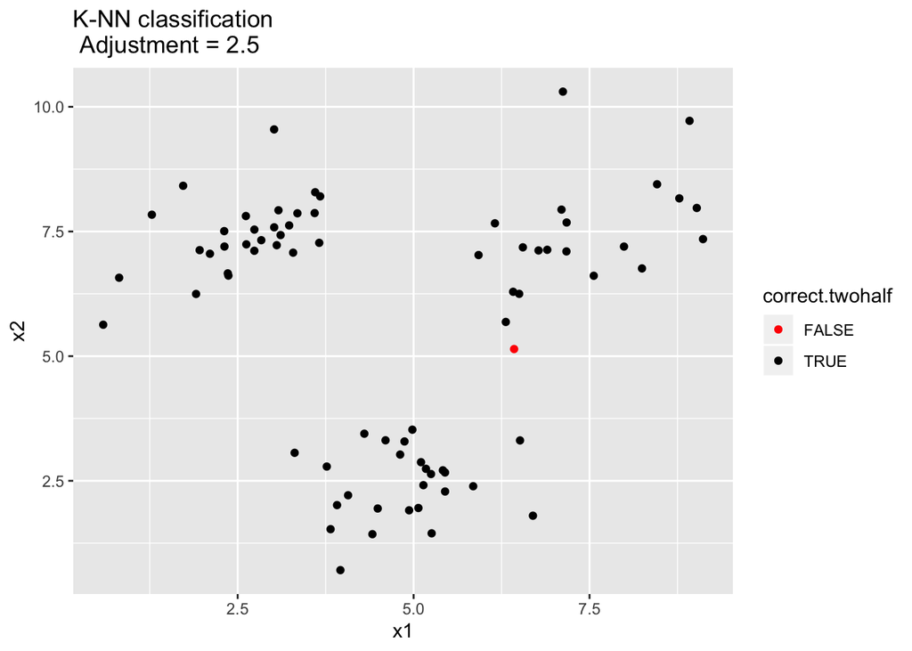

```r
cbind(test.twohalf, correct.twohalf) %>%
  ggplot(aes(x1, x2,  colour = correct.twohalf)) +
  geom_point() +
  scale_colour_manual(values = c("red", "black")) +
  ggtitle("K-NN classification \n Adjustment = 2.5")
```

The clusters are visisbly separated. It is quite difficult to misclassify values based on their three closest neighbors - except for the values that are somewhat in between two (or more) clusters. Now we only make 1 misclassification given that we have `set.seed(123)` - different seeds may yield different data and, hence, different results. The misclassified value is indeed one of those values: in between two clusters.

6. **Write a function that determines the optimum `k` with respect to classification error. Have the function return the following:**
- The optimum `k` (i.e. the lowest `k` with the most correct predictions)
- The proportion correctly predicted for optimum `k`
- A data frame with the proportion correct for every `k`

```r
Optimize.knn <- function(train.set, test.set, train.class, test.class, min = 1, max = NULL) {
  if (is.null(max)) {
    max <- nrow(train.set)
  }
  if (!is.matrix(train.class)) {
    train.class <- as.matrix(train.class)
  }
  output <- list() #object to store in
  for (i in min:max){
    output[[i]] <- knn(train = train.set,
                       test = test.set,
                       cl = train.class,
                       k = i)
  }
  compare <- function(x) mean(x == test.class)
  correct <- data.frame(k = 1:max,
                        p.correct = sapply(output, compare))
  optimum <- min(correct$k[which.max(correct$p.correct)])
  result <- list(optimum.k = optimum,
                 max.p.correct = max(correct$p.correct),
                 results = correct)
  return(result)
}
```

7. **Execute your function twice: once for the data set based on the `.5` adjustment and once for the data set based on the `2.5` adjustment. Does the previously used `k=3` yield the optimal classification prediction?**

```r
Optimize.knn(train.half, test.half, class.half, class.test.half)
```

```
## $optimum.k
## [1] 10
##
## $max.p.correct
## [1] 0.5538462
##
## $results
##     k p.correct
## 1   1 0.4000000
## 2   2 0.3538462
## 3   3 0.3846154
## 4   4 0.4307692
## 5   5 0.4461538
## 6   6 0.4769231
## 7   7 0.4923077
```

[output cut: 28 more lines]

```r
Optimize.knn(train.twohalf, test.twohalf, class.twohalf, class.test.twohalf)
```

```
## $optimum.k
## [1] 1
##
## $max.p.correct
## [1] 1
##
## $results
##     k p.correct
## 1   1 1.0000000
## 2   2 1.0000000
## 3   3 0.9866667
## 4   4 0.9866667
## 5   5 1.0000000
## 6   6 1.0000000
## 7   7 1.0000000
```

[output cut: 18 more lines]

Please note that any ties are solved on a random basis. That is why running the same code again, *slightly* different results may be obtained.

```r
Optimize.knn(train.twohalf, test.twohalf, class.twohalf, class.test.twohalf)
```

```
## $optimum.k
## [1] 1
##
## $max.p.correct
## [1] 1
##
## $results
##     k p.correct
## 1   1 1.0000000
## 2   2 0.9866667
## 3   3 0.9866667
## 4   4 0.9866667
## 5   5 1.0000000
## 6   6 1.0000000
## 7   7 1.0000000
```

[output cut: 18 more lines]

End of Practical